# Risk Factor Analysis

## Outcome Variable

**Outcome Variable:** ever_stunted

## Predictor Variables

**Intervention Variable:** perdiar6

**Adjustment Set:**

- arm
- sex
- W_mage
- meducyrs
- feducyrs
- hhwealth_quart
- hfoodsec
- W_mhtcm
- W_mwtkg
- W_mbmi
- W_birthwt
- W_birthlen
- W_nrooms
- month
- brthmon
- impfloor
- impsan
- safeh20
- delta_W_mage
- delta_meducyrs
- delta_feducyrs
- delta_hhwealth_quart
- delta_hfoodsec
- delta_W_mhtcm
- delta_W_mwtkg
- delta_W_mbmi
- delta_W_birthwt
- delta_W_birthlen
- delta_W_nrooms
- delta_month
- delta_brthmon
- delta_impfloor
- delta_impsan
- delta_safeh20

## Stratifying Variables

The analysis was stratified on these variable(s):

- agecat
- studyid
- country

## Data Summary

| agecat | studyid | country | perdiar6 | ever_stunted | n_cell | n |
| --- | --- | --- | --- | --- | --- | --- |
| 0-24 months (no birth st.) | CMIN | BANGLADESH | 0% | 0 | 20 | 168 |
| 0-24 months (no birth st.) | CMIN | BANGLADESH | 0% | 1 | 48 | 168 |
| 0-24 months (no birth st.) | CMIN | BANGLADESH | (0%, 5%] | 0 | 5 | 168 |
| 0-24 months (no birth st.) | CMIN | BANGLADESH | (0%, 5%] | 1 | 29 | 168 |
| 0-24 months (no birth st.) | CMIN | BANGLADESH | >5% | 0 | 16 | 168 |
| 0-24 months (no birth st.) | CMIN | BANGLADESH | >5% | 1 | 50 | 168 |
| 0-24 months (no birth st.) | CONTENT | PERU | 0% | 0 | 84 | 195 |
| 0-24 months (no birth st.) | CONTENT | PERU | 0% | 1 | 19 | 195 |
| 0-24 months (no birth st.) | CONTENT | PERU | (0%, 5%] | 0 | 31 | 195 |
| 0-24 months (no birth st.) | CONTENT | PERU | (0%, 5%] | 1 | 6 | 195 |
| 0-24 months (no birth st.) | CONTENT | PERU | >5% | 0 | 47 | 195 |
| 0-24 months (no birth st.) | CONTENT | PERU | >5% | 1 | 8 | 195 |
| 0-24 months (no birth st.) | EE | PAKISTAN | 0% | 0 | 38 | 213 |
| 0-24 months (no birth st.) | EE | PAKISTAN | 0% | 1 | 161 | 213 |
| 0-24 months (no birth st.) | EE | PAKISTAN | (0%, 5%] | 0 | 2 | 213 |
| 0-24 months (no birth st.) | EE | PAKISTAN | (0%, 5%] | 1 | 11 | 213 |
| 0-24 months (no birth st.) | EE | PAKISTAN | >5% | 0 | 1 | 213 |
| 0-24 months (no birth st.) | EE | PAKISTAN | >5% | 1 | 0 | 213 |
| 0-24 months (no birth st.) | MAL-ED | BANGLADESH | 0% | 0 | 35 | 217 |
| 0-24 months (no birth st.) | MAL-ED | BANGLADESH | 0% | 1 | 37 | 217 |
| 0-24 months (no birth st.) | MAL-ED | BANGLADESH | (0%, 5%] | 0 | 41 | 217 |
| 0-24 months (no birth st.) | MAL-ED | BANGLADESH | (0%, 5%] | 1 | 44 | 217 |
| 0-24 months (no birth st.) | MAL-ED | BANGLADESH | >5% | 0 | 27 | 217 |
| 0-24 months (no birth st.) | MAL-ED | BANGLADESH | >5% | 1 | 33 | 217 |
| 0-24 months (no birth st.) | MAL-ED | BRAZIL | 0% | 0 | 156 | 202 |
| 0-24 months (no birth st.) | MAL-ED | BRAZIL | 0% | 1 | 30 | 202 |
| 0-24 months (no birth st.) | MAL-ED | BRAZIL | (0%, 5%] | 0 | 12 | 202 |
| 0-24 months (no birth st.) | MAL-ED | BRAZIL | (0%, 5%] | 1 | 2 | 202 |
| 0-24 months (no birth st.) | MAL-ED | BRAZIL | >5% | 0 | 2 | 202 |
| 0-24 months (no birth st.) | MAL-ED | BRAZIL | >5% | 1 | 0 | 202 |

[output cut: 126 more lines]

The following strata were considered:

- agecat: 0-24 months (no birth st.), studyid: CMIN, country: BANGLADESH
- agecat: 0-24 months (no birth st.), studyid: CONTENT, country: PERU
- agecat: 0-24 months (no birth st.), studyid: EE, country: PAKISTAN
- agecat: 0-24 months (no birth st.), studyid: MAL-ED, country: BANGLADESH
- agecat: 0-24 months (no birth st.), studyid: MAL-ED, country: BRAZIL
- agecat: 0-24 months (no birth st.), studyid: MAL-ED, country: INDIA
- agecat: 0-24 months (no birth st.), studyid: MAL-ED, country: NEPAL
- agecat: 0-24 months (no birth st.), studyid: MAL-ED, country: PERU
- agecat: 0-24 months (no birth st.), studyid: MAL-ED, country: SOUTH AFRICA
- agecat: 0-24 months (no birth st.), studyid: MAL-ED, country: TANZANIA, UNITED REPUBLIC OF
- agecat: 0-24 months (no birth st.), studyid: NIH-Birth, country: BANGLADESH
- agecat: 0-24 months (no birth st.), studyid: NIH-Crypto, country: BANGLADESH
- agecat: 0-24 months (no birth st.), studyid: PROVIDE, country: BANGLADESH
- agecat: 0-6 months (no birth st.), studyid: CMIN, country: BANGLADESH
- agecat: 0-6 months (no birth st.), studyid: CONTENT, country: PERU
- agecat: 0-6 months (no birth st.), studyid: EE, country: PAKISTAN
- agecat: 0-6 months (no birth st.), studyid: MAL-ED, country: BANGLADESH
- agecat: 0-6 months (no birth st.), studyid: MAL-ED, country: BRAZIL
- agecat: 0-6 months (no birth st.), studyid: MAL-ED, country: INDIA
- agecat: 0-6 months (no birth st.), studyid: MAL-ED, country: NEPAL
- agecat: 0-6 months (no birth st.), studyid: MAL-ED, country: PERU
- agecat: 0-6 months (no birth st.), studyid: MAL-ED, country: SOUTH AFRICA
- agecat: 0-6 months (no birth st.), studyid: MAL-ED, country: TANZANIA, UNITED REPUBLIC OF
- agecat: 0-6 months (no birth st.), studyid: NIH-Birth, country: BANGLADESH
- agecat: 0-6 months (no birth st.), studyid: NIH-Crypto, country: BANGLADESH
- agecat: 0-6 months (no birth st.), studyid: PROVIDE, country: BANGLADESH

### Dropped Strata

Some strata were dropped due to rare outcomes:

- agecat: 0-24 months (no birth st.), studyid: EE, country: PAKISTAN
- agecat: 0-24 months (no birth st.), studyid: MAL-ED, country: BRAZIL
- agecat: 0-24 months (no birth st.), studyid: MAL-ED, country: SOUTH AFRICA
- agecat: 0-6 months (no birth st.), studyid: CONTENT, country: PERU
- agecat: 0-6 months (no birth st.), studyid: EE, country: PAKISTAN
- agecat: 0-6 months (no birth st.), studyid: MAL-ED, country: BRAZIL
- agecat: 0-6 months (no birth st.), studyid: MAL-ED, country: NEPAL
- agecat: 0-6 months (no birth st.), studyid: MAL-ED, country: SOUTH AFRICA

## Methods Detail

We're interested in the causal parameters $E[Y_a]$ for all values of $a \in \mathcal{A}$. These parameters represent the mean outcome if, possibly contrary to fact, we intervened to set all units to have $A=a$. Under the randomization and positivity assumptions, these are identified by the statistical parameters $\psi_a=E_W[E_{Y|A,W}(Y|A=a,W)]$. In addition, we're interested in the mean of $Y$, $E[Y]$ under no intervention (the observed mean). We will estimate these parameters by using SuperLearner to fit the relevant likelihood factors -- $E_{Y|A,W}(Y|A=a,W)$ and $p(A=a|W)$, and then updating our likelihood fit using a joint TMLE.

For unadjusted analyses ($W=\{\}$), initial likelihoods were estimated using Lrnr_glm to estimate the simple $E(Y|A)$ and Lrnr_mean to estimate $p(A)$. For adjusted analyses, a small library containing Lrnr_glmnet, Lrnr_xgboost, and Lrnr_mean was used.

Having estimated these parameters, we will then use the delta method to estimate relative risks and attributable risks relative to a prespecified baseline level of $A$.

# Results Detail

## Results Plots

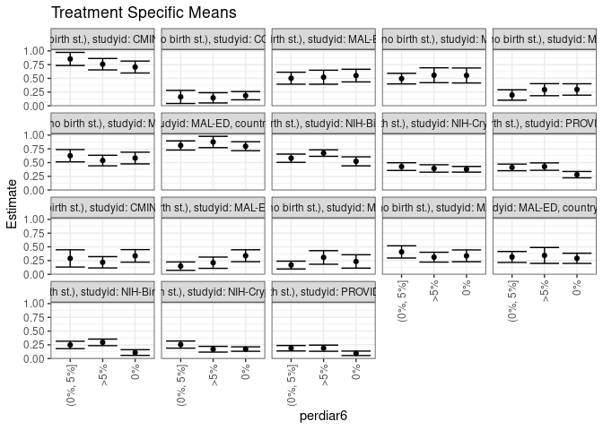

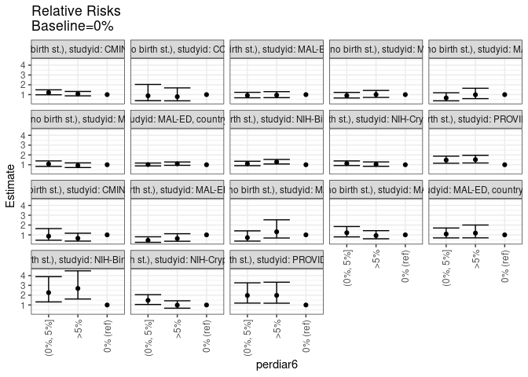

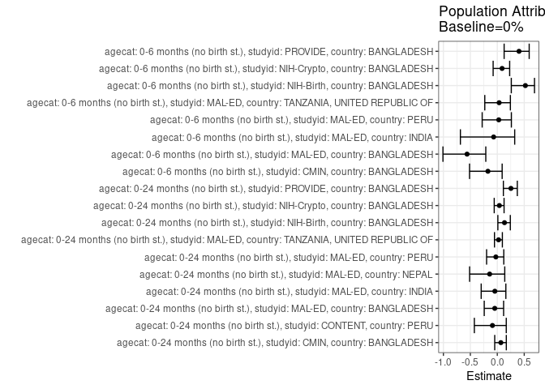

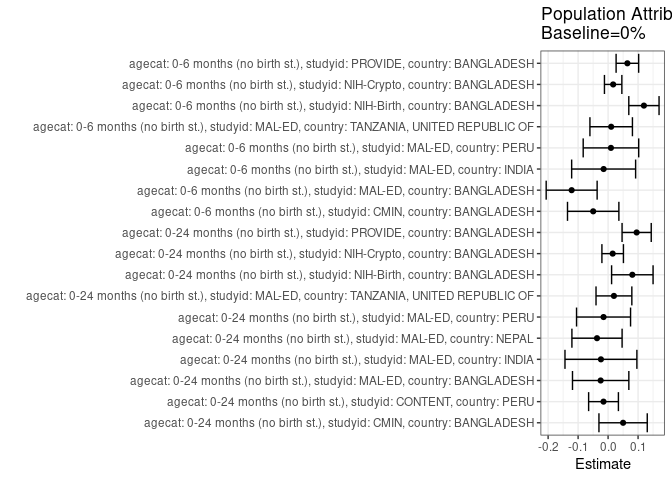

## Results Table

### Parameter: TSM

| agecat | studyid | country | intervention_level | baseline_level | estimate | ci_lower | ci_upper |
| --- | --- | --- | --- | --- | --- | --- | --- |
| 0-24 months (no birth st.) | CMIN | BANGLADESH | 0% | NA | 0.7058824 | 0.5972606 | 0.8145041 |
| 0-24 months (no birth st.) | CMIN | BANGLADESH | (0%, 5%] | NA | 0.8529412 | 0.7335396 | 0.9723428 |
| 0-24 months (no birth st.) | CMIN | BANGLADESH | >5% | NA | 0.7575758 | 0.6538770 | 0.8612745 |
| 0-24 months (no birth st.) | CONTENT | PERU | 0% | NA | 0.1844660 | 0.1093686 | 0.2595635 |
| 0-24 months (no birth st.) | CONTENT | PERU | (0%, 5%] | NA | 0.1621622 | 0.0430878 | 0.2812366 |
| 0-24 months (no birth st.) | CONTENT | PERU | >5% | NA | 0.1454545 | 0.0520400 | 0.2388691 |
| 0-24 months (no birth st.) | MAL-ED | BANGLADESH | 0% | NA | 0.5500906 | 0.4349478 | 0.6652334 |
| 0-24 months (no birth st.) | MAL-ED | BANGLADESH | (0%, 5%] | NA | 0.5025504 | 0.3938766 | 0.6112242 |
| 0-24 months (no birth st.) | MAL-ED | BANGLADESH | >5% | NA | 0.5206601 | 0.3932796 | 0.6480406 |
| 0-24 months (no birth st.) | MAL-ED | INDIA | 0% | NA | 0.5524304 | 0.4161443 | 0.6887164 |
| 0-24 months (no birth st.) | MAL-ED | INDIA | (0%, 5%] | NA | 0.4950819 | 0.3989299 | 0.5912340 |
| 0-24 months (no birth st.) | MAL-ED | INDIA | >5% | NA | 0.5565384 | 0.4211283 | 0.6919486 |
| 0-24 months (no birth st.) | MAL-ED | NEPAL | 0% | NA | 0.2976385 | 0.1938345 | 0.4014425 |
| 0-24 months (no birth st.) | MAL-ED | NEPAL | (0%, 5%] | NA | 0.1967357 | 0.1021553 | 0.2913161 |
| 0-24 months (no birth st.) | MAL-ED | NEPAL | >5% | NA | 0.2938512 | 0.1838835 | 0.4038189 |
| 0-24 months (no birth st.) | MAL-ED | PERU | 0% | NA | 0.5827897 | 0.4767326 | 0.6888467 |
| 0-24 months (no birth st.) | MAL-ED | PERU | (0%, 5%] | NA | 0.6253909 | 0.5135211 | 0.7372607 |
| 0-24 months (no birth st.) | MAL-ED | PERU | >5% | NA | 0.5376255 | 0.4415397 | 0.6337113 |
| 0-24 months (no birth st.) | MAL-ED | TANZANIA, UNITED REPUBLIC OF | 0% | NA | 0.7978723 | 0.7165036 | 0.8792411 |
| 0-24 months (no birth st.) | MAL-ED | TANZANIA, UNITED REPUBLIC OF | (0%, 5%] | NA | 0.8117647 | 0.7284737 | 0.8950557 |
| 0-24 months (no birth st.) | MAL-ED | TANZANIA, UNITED REPUBLIC OF | >5% | NA | 0.8750000 | 0.7722762 | 0.9777238 |
| 0-24 months (no birth st.) | NIH-Birth | BANGLADESH | 0% | NA | 0.5233055 | 0.4408705 | 0.6057404 |
| 0-24 months (no birth st.) | NIH-Birth | BANGLADESH | (0%, 5%] | NA | 0.5797453 | 0.5046475 | 0.6548431 |
| 0-24 months (no birth st.) | NIH-Birth | BANGLADESH | >5% | NA | 0.6729669 | 0.6144517 | 0.7314821 |
| 0-24 months (no birth st.) | NIH-Crypto | BANGLADESH | 0% | NA | 0.3782808 | 0.3265327 | 0.4300289 |
| 0-24 months (no birth st.) | NIH-Crypto | BANGLADESH | (0%, 5%] | NA | 0.4269294 | 0.3564031 | 0.4974558 |
| 0-24 months (no birth st.) | NIH-Crypto | BANGLADESH | >5% | NA | 0.3935397 | 0.3261169 | 0.4609625 |
| 0-24 months (no birth st.) | PROVIDE | BANGLADESH | 0% | NA | 0.2807286 | 0.2230888 | 0.3383684 |
| 0-24 months (no birth st.) | PROVIDE | BANGLADESH | (0%, 5%] | NA | 0.4126482 | 0.3522636 | 0.4730329 |
| 0-24 months (no birth st.) | PROVIDE | BANGLADESH | >5% | NA | 0.4273937 | 0.3599114 | 0.4948761 |
| 0-6 months (no birth st.) | CMIN | BANGLADESH | 0% | NA | 0.3354109 | 0.2215044 | 0.4493174 |
| 0-6 months (no birth st.) | CMIN | BANGLADESH | (0%, 5%] | NA | 0.2895684 | 0.1324905 | 0.4466462 |
| 0-6 months (no birth st.) | CMIN | BANGLADESH | >5% | NA | 0.2187755 | 0.1157639 | 0.3217871 |
| 0-6 months (no birth st.) | MAL-ED | BANGLADESH | 0% | NA | 0.3380970 | 0.2291710 | 0.4470229 |
| 0-6 months (no birth st.) | MAL-ED | BANGLADESH | (0%, 5%] | NA | 0.1484639 | 0.0725894 | 0.2243383 |
| 0-6 months (no birth st.) | MAL-ED | BANGLADESH | >5% | NA | 0.2110972 | 0.1084040 | 0.3137904 |
| 0-6 months (no birth st.) | MAL-ED | INDIA | 0% | NA | 0.2339084 | 0.1120151 | 0.3558017 |
| 0-6 months (no birth st.) | MAL-ED | INDIA | (0%, 5%] | NA | 0.1680059 | 0.0967087 | 0.2393031 |
| 0-6 months (no birth st.) | MAL-ED | INDIA | >5% | NA | 0.3070297 | 0.1835489 | 0.4305105 |
| 0-6 months (no birth st.) | MAL-ED | PERU | 0% | NA | 0.3363223 | 0.2282419 | 0.4444028 |
| 0-6 months (no birth st.) | MAL-ED | PERU | (0%, 5%] | NA | 0.4077850 | 0.2966830 | 0.5188870 |
| 0-6 months (no birth st.) | MAL-ED | PERU | >5% | NA | 0.3121482 | 0.2226039 | 0.4016926 |
| 0-6 months (no birth st.) | MAL-ED | TANZANIA, UNITED REPUBLIC OF | 0% | NA | 0.2910486 | 0.1984203 | 0.3836768 |
| 0-6 months (no birth st.) | MAL-ED | TANZANIA, UNITED REPUBLIC OF | (0%, 5%] | NA | 0.3156506 | 0.2158439 | 0.4154573 |
| 0-6 months (no birth st.) | MAL-ED | TANZANIA, UNITED REPUBLIC OF | >5% | NA | 0.3436925 | 0.1990429 | 0.4883421 |
| 0-6 months (no birth st.) | NIH-Birth | BANGLADESH | 0% | NA | 0.1096547 | 0.0580815 | 0.1612279 |
| 0-6 months (no birth st.) | NIH-Birth | BANGLADESH | (0%, 5%] | NA | 0.2479475 | 0.1807703 | 0.3151248 |
| 0-6 months (no birth st.) | NIH-Birth | BANGLADESH | >5% | NA | 0.2945679 | 0.2350144 | 0.3541215 |
| 0-6 months (no birth st.) | NIH-Crypto | BANGLADESH | 0% | NA | 0.1729981 | 0.1327293 | 0.2132668 |
| 0-6 months (no birth st.) | NIH-Crypto | BANGLADESH | (0%, 5%] | NA | 0.2544668 | 0.1896460 | 0.3192876 |
| 0-6 months (no birth st.) | NIH-Crypto | BANGLADESH | >5% | NA | 0.1698062 | 0.1179225 | 0.2216898 |
| 0-6 months (no birth st.) | PROVIDE | BANGLADESH | 0% | NA | 0.0952241 | 0.0546441 | 0.1358042 |
| 0-6 months (no birth st.) | PROVIDE | BANGLADESH | (0%, 5%] | NA | 0.1879337 | 0.1379824 | 0.2378849 |
| 0-6 months (no birth st.) | PROVIDE | BANGLADESH | >5% | NA | 0.1886950 | 0.1330920 | 0.2442980 |

### Parameter: E(Y)

| agecat | studyid | country | intervention_level | baseline_level | estimate | ci_lower | ci_upper |
| --- | --- | --- | --- | --- | --- | --- | --- |
| 0-24 months (no birth st.) | CMIN | BANGLADESH | NA | NA | 0.7559524 | 0.6908084 | 0.8210964 |
| 0-24 months (no birth st.) | CONTENT | PERU | NA | NA | 0.1692308 | 0.1164681 | 0.2219935 |
| 0-24 months (no birth st.) | MAL-ED | BANGLADESH | NA | NA | 0.5253456 | 0.4587520 | 0.5919392 |
| 0-24 months (no birth st.) | MAL-ED | INDIA | NA | NA | 0.5285714 | 0.4608954 | 0.5962474 |
| 0-24 months (no birth st.) | MAL-ED | NEPAL | NA | NA | 0.2606635 | 0.2012891 | 0.3200380 |
| 0-24 months (no birth st.) | MAL-ED | PERU | NA | NA | 0.5676692 | 0.5080232 | 0.6273151 |
| 0-24 months (no birth st.) | MAL-ED | TANZANIA, UNITED REPUBLIC OF | NA | NA | 0.8173516 | 0.7660617 | 0.8686415 |
| 0-24 months (no birth st.) | NIH-Birth | BANGLADESH | NA | NA | 0.6041667 | 0.5624147 | 0.6459187 |
| 0-24 months (no birth st.) | NIH-Crypto | BANGLADESH | NA | NA | 0.3935681 | 0.3560687 | 0.4310676 |
| 0-24 months (no birth st.) | PROVIDE | BANGLADESH | NA | NA | 0.3759874 | 0.3382238 | 0.4137509 |
| 0-6 months (no birth st.) | CMIN | BANGLADESH | NA | NA | 0.2857143 | 0.2171983 | 0.3542303 |
| 0-6 months (no birth st.) | MAL-ED | BANGLADESH | NA | NA | 0.2165899 | 0.1616567 | 0.2715231 |
| 0-6 months (no birth st.) | MAL-ED | INDIA | NA | NA | 0.2190476 | 0.1629743 | 0.2751210 |
| 0-6 months (no birth st.) | MAL-ED | PERU | NA | NA | 0.3458647 | 0.2885967 | 0.4031327 |
| 0-6 months (no birth st.) | MAL-ED | TANZANIA, UNITED REPUBLIC OF | NA | NA | 0.3013699 | 0.2404592 | 0.3622805 |
| 0-6 months (no birth st.) | NIH-Birth | BANGLADESH | NA | NA | 0.2291667 | 0.1932828 | 0.2650505 |
| 0-6 months (no birth st.) | NIH-Crypto | BANGLADESH | NA | NA | 0.1898928 | 0.1597870 | 0.2199986 |
| 0-6 months (no birth st.) | PROVIDE | BANGLADESH | NA | NA | 0.1595577 | 0.1310079 | 0.1881074 |

### Parameter: RR

| agecat | studyid | country | intervention_level | baseline_level | estimate | ci_lower | ci_upper |
| --- | --- | --- | --- | --- | --- | --- | --- |
| 0-24 months (no birth st.) | CMIN | BANGLADESH | 0% | 0% | 1.0000000 | 1.0000000 | 1.000000 |
| 0-24 months (no birth st.) | CMIN | BANGLADESH | (0%, 5%] | 0% | 1.2083333 | 0.9813886 | 1.487759 |
| 0-24 months (no birth st.) | CMIN | BANGLADESH | >5% | 0% | 1.0732323 | 0.8734742 | 1.318674 |
| 0-24 months (no birth st.) | CONTENT | PERU | 0% | 0% | 1.0000000 | 1.0000000 | 1.000000 |
| 0-24 months (no birth st.) | CONTENT | PERU | (0%, 5%] | 0% | 0.8790896 | 0.3796656 | 2.035471 |
| 0-24 months (no birth st.) | CONTENT | PERU | >5% | 0% | 0.7885167 | 0.3686200 | 1.686720 |
| 0-24 months (no birth st.) | MAL-ED | BANGLADESH | 0% | 0% | 1.0000000 | 1.0000000 | 1.000000 |
| 0-24 months (no birth st.) | MAL-ED | BANGLADESH | (0%, 5%] | 0% | 0.9135775 | 0.6777073 | 1.231540 |
| 0-24 months (no birth st.) | MAL-ED | BANGLADESH | >5% | 0% | 0.9464987 | 0.6893546 | 1.299563 |
| 0-24 months (no birth st.) | MAL-ED | INDIA | 0% | 0% | 1.0000000 | 1.0000000 | 1.000000 |
| 0-24 months (no birth st.) | MAL-ED | INDIA | (0%, 5%] | 0% | 0.8961888 | 0.6567297 | 1.222960 |
| 0-24 months (no birth st.) | MAL-ED | INDIA | >5% | 0% | 1.0074364 | 0.7134388 | 1.422586 |
| 0-24 months (no birth st.) | MAL-ED | NEPAL | 0% | 0% | 1.0000000 | 1.0000000 | 1.000000 |
| 0-24 months (no birth st.) | MAL-ED | NEPAL | (0%, 5%] | 0% | 0.6609889 | 0.3674574 | 1.188998 |
| 0-24 months (no birth st.) | MAL-ED | NEPAL | >5% | 0% | 0.9872756 | 0.5912779 | 1.648486 |
| 0-24 months (no birth st.) | MAL-ED | PERU | 0% | 0% | 1.0000000 | 1.0000000 | 1.000000 |
| 0-24 months (no birth st.) | MAL-ED | PERU | (0%, 5%] | 0% | 1.0730988 | 0.8295202 | 1.388201 |
| 0-24 months (no birth st.) | MAL-ED | PERU | >5% | 0% | 0.9225035 | 0.7159816 | 1.188596 |
| 0-24 months (no birth st.) | MAL-ED | TANZANIA, UNITED REPUBLIC OF | 0% | 0% | 1.0000000 | 1.0000000 | 1.000000 |
| 0-24 months (no birth st.) | MAL-ED | TANZANIA, UNITED REPUBLIC OF | (0%, 5%] | 0% | 1.0174118 | 0.8803783 | 1.175775 |
| 0-24 months (no birth st.) | MAL-ED | TANZANIA, UNITED REPUBLIC OF | >5% | 0% | 1.0966667 | 0.9387248 | 1.281182 |
| 0-24 months (no birth st.) | NIH-Birth | BANGLADESH | 0% | 0% | 1.0000000 | 1.0000000 | 1.000000 |
| 0-24 months (no birth st.) | NIH-Birth | BANGLADESH | (0%, 5%] | 0% | 1.1078526 | 0.9052953 | 1.355732 |
| 0-24 months (no birth st.) | NIH-Birth | BANGLADESH | >5% | 0% | 1.2859925 | 1.0760802 | 1.536853 |
| 0-24 months (no birth st.) | NIH-Crypto | BANGLADESH | 0% | 0% | 1.0000000 | 1.0000000 | 1.000000 |
| 0-24 months (no birth st.) | NIH-Crypto | BANGLADESH | (0%, 5%] | 0% | 1.1286045 | 0.9191122 | 1.385846 |
| 0-24 months (no birth st.) | NIH-Crypto | BANGLADESH | >5% | 0% | 1.0403373 | 0.8402137 | 1.288127 |
| 0-24 months (no birth st.) | PROVIDE | BANGLADESH | 0% | 0% | 1.0000000 | 1.0000000 | 1.000000 |
| 0-24 months (no birth st.) | PROVIDE | BANGLADESH | (0%, 5%] | 0% | 1.4699187 | 1.1524082 | 1.874910 |
| 0-24 months (no birth st.) | PROVIDE | BANGLADESH | >5% | 0% | 1.5224445 | 1.1814515 | 1.961856 |
| 0-6 months (no birth st.) | CMIN | BANGLADESH | 0% | 0% | 1.0000000 | 1.0000000 | 1.000000 |
| 0-6 months (no birth st.) | CMIN | BANGLADESH | (0%, 5%] | 0% | 0.8633241 | 0.4542162 | 1.640912 |
| 0-6 months (no birth st.) | CMIN | BANGLADESH | >5% | 0% | 0.6522612 | 0.3644198 | 1.167458 |
| 0-6 months (no birth st.) | MAL-ED | BANGLADESH | 0% | 0% | 1.0000000 | 1.0000000 | 1.000000 |
| 0-6 months (no birth st.) | MAL-ED | BANGLADESH | (0%, 5%] | 0% | 0.4391163 | 0.2401003 | 0.803094 |
| 0-6 months (no birth st.) | MAL-ED | BANGLADESH | >5% | 0% | 0.6243688 | 0.3485835 | 1.118344 |
| 0-6 months (no birth st.) | MAL-ED | INDIA | 0% | 0% | 1.0000000 | 1.0000000 | 1.000000 |
| 0-6 months (no birth st.) | MAL-ED | INDIA | (0%, 5%] | 0% | 0.7182552 | 0.3663858 | 1.408053 |
| 0-6 months (no birth st.) | MAL-ED | INDIA | >5% | 0% | 1.3126067 | 0.6790726 | 2.537190 |
| 0-6 months (no birth st.) | MAL-ED | PERU | 0% | 0% | 1.0000000 | 1.0000000 | 1.000000 |
| 0-6 months (no birth st.) | MAL-ED | PERU | (0%, 5%] | 0% | 1.2124827 | 0.7950019 | 1.849196 |
| 0-6 months (no birth st.) | MAL-ED | PERU | >5% | 0% | 0.9281222 | 0.6031473 | 1.428193 |
| 0-6 months (no birth st.) | MAL-ED | TANZANIA, UNITED REPUBLIC OF | 0% | 0% | 1.0000000 | 1.0000000 | 1.000000 |
| 0-6 months (no birth st.) | MAL-ED | TANZANIA, UNITED REPUBLIC OF | (0%, 5%] | 0% | 1.0845289 | 0.6922602 | 1.699076 |
| 0-6 months (no birth st.) | MAL-ED | TANZANIA, UNITED REPUBLIC OF | >5% | 0% | 1.1808766 | 0.6964720 | 2.002191 |
| 0-6 months (no birth st.) | NIH-Birth | BANGLADESH | 0% | 0% | 1.0000000 | 1.0000000 | 1.000000 |
| 0-6 months (no birth st.) | NIH-Birth | BANGLADESH | (0%, 5%] | 0% | 2.2611667 | 1.3141705 | 3.890572 |
| 0-6 months (no birth st.) | NIH-Birth | BANGLADESH | >5% | 0% | 2.6863234 | 1.6102502 | 4.481498 |
| 0-6 months (no birth st.) | NIH-Crypto | BANGLADESH | 0% | 0% | 1.0000000 | 1.0000000 | 1.000000 |
| 0-6 months (no birth st.) | NIH-Crypto | BANGLADESH | (0%, 5%] | 0% | 1.4709231 | 1.0529643 | 2.054784 |
| 0-6 months (no birth st.) | NIH-Crypto | BANGLADESH | >5% | 0% | 0.9815496 | 0.6743884 | 1.428613 |
| 0-6 months (no birth st.) | PROVIDE | BANGLADESH | 0% | 0% | 1.0000000 | 1.0000000 | 1.000000 |
| 0-6 months (no birth st.) | PROVIDE | BANGLADESH | (0%, 5%] | 0% | 1.9735925 | 1.1951378 | 3.259095 |
| 0-6 months (no birth st.) | PROVIDE | BANGLADESH | >5% | 0% | 1.9815874 | 1.1814034 | 3.323749 |

### Parameter: PAR

| agecat | studyid | country | intervention_level | baseline_level | estimate | ci_lower | ci_upper |
| --- | --- | --- | --- | --- | --- | --- | --- |
| 0-24 months (no birth st.) | CMIN | BANGLADESH | 0% | NA | 0.0500700 | -0.0304974 | 0.1306374 |
| 0-24 months (no birth st.) | CONTENT | PERU | 0% | NA | -0.0152353 | -0.0648918 | 0.0344213 |
| 0-24 months (no birth st.) | MAL-ED | BANGLADESH | 0% | NA | -0.0247450 | -0.1186987 | 0.0692087 |
| 0-24 months (no birth st.) | MAL-ED | INDIA | 0% | NA | -0.0238589 | -0.1437603 | 0.0960424 |
| 0-24 months (no birth st.) | MAL-ED | NEPAL | 0% | NA | -0.0369750 | -0.1206571 | 0.0467072 |
| 0-24 months (no birth st.) | MAL-ED | PERU | 0% | NA | -0.0151205 | -0.1051855 | 0.0749446 |
| 0-24 months (no birth st.) | MAL-ED | TANZANIA, UNITED REPUBLIC OF | 0% | NA | 0.0194793 | -0.0402523 | 0.0792108 |
| 0-24 months (no birth st.) | NIH-Birth | BANGLADESH | 0% | NA | 0.0808612 | 0.0117067 | 0.1500157 |
| 0-24 months (no birth st.) | NIH-Crypto | BANGLADESH | 0% | NA | 0.0152873 | -0.0206198 | 0.0511944 |
| 0-24 months (no birth st.) | PROVIDE | BANGLADESH | 0% | NA | 0.0952588 | 0.0466188 | 0.1438987 |
| 0-6 months (no birth st.) | CMIN | BANGLADESH | 0% | NA | -0.0496967 | -0.1353687 | 0.0359754 |
| 0-6 months (no birth st.) | MAL-ED | BANGLADESH | 0% | NA | -0.1215071 | -0.2064744 | -0.0365398 |
| 0-6 months (no birth st.) | MAL-ED | INDIA | 0% | NA | -0.0148608 | -0.1215334 | 0.0918119 |
| 0-6 months (no birth st.) | MAL-ED | PERU | 0% | NA | 0.0095423 | -0.0830233 | 0.1021079 |
| 0-6 months (no birth st.) | MAL-ED | TANZANIA, UNITED REPUBLIC OF | 0% | NA | 0.0103213 | -0.0605553 | 0.0811979 |
| 0-6 months (no birth st.) | NIH-Birth | BANGLADESH | 0% | NA | 0.1195120 | 0.0690609 | 0.1699631 |
| 0-6 months (no birth st.) | NIH-Crypto | BANGLADESH | 0% | NA | 0.0168948 | -0.0121292 | 0.0459187 |
| 0-6 months (no birth st.) | PROVIDE | BANGLADESH | 0% | NA | 0.0643335 | 0.0267294 | 0.1019376 |

### Parameter: PAF

| agecat | studyid | country | intervention_level | baseline_level | estimate | ci_lower | ci_upper |
| --- | --- | --- | --- | --- | --- | --- | --- |
| 0-24 months (no birth st.) | CMIN | BANGLADESH | 0% | NA | 0.0662344 | -0.0474806 | 0.1676044 |
| 0-24 months (no birth st.) | CONTENT | PERU | 0% | NA | -0.0900265 | -0.4257630 | 0.1666513 |
| 0-24 months (no birth st.) | MAL-ED | BANGLADESH | 0% | NA | -0.0471023 | -0.2422453 | 0.1173859 |
| 0-24 months (no birth st.) | MAL-ED | INDIA | 0% | NA | -0.0451385 | -0.2987386 | 0.1589420 |
| 0-24 months (no birth st.) | MAL-ED | NEPAL | 0% | NA | -0.1418494 | -0.5136471 | 0.1386235 |
| 0-24 months (no birth st.) | MAL-ED | PERU | 0% | NA | -0.0266361 | -0.1983669 | 0.1204850 |
| 0-24 months (no birth st.) | MAL-ED | TANZANIA, UNITED REPUBLIC OF | 0% | NA | 0.0238322 | -0.0521798 | 0.0943528 |
| 0-24 months (no birth st.) | NIH-Birth | BANGLADESH | 0% | NA | 0.1338392 | 0.0105520 | 0.2417647 |
| 0-24 months (no birth st.) | NIH-Crypto | BANGLADESH | 0% | NA | 0.0388429 | -0.0569182 | 0.1259276 |
| 0-24 months (no birth st.) | PROVIDE | BANGLADESH | 0% | NA | 0.2533563 | 0.1130009 | 0.3715023 |
| 0-6 months (no birth st.) | CMIN | BANGLADESH | 0% | NA | -0.1739383 | -0.5149959 | 0.0903400 |
| 0-6 months (no birth st.) | MAL-ED | BANGLADESH | 0% | NA | -0.5610009 | -1.0082686 | -0.2133456 |
| 0-6 months (no birth st.) | MAL-ED | INDIA | 0% | NA | -0.0678427 | -0.6845862 | 0.3231050 |
| 0-6 months (no birth st.) | MAL-ED | PERU | 0% | NA | 0.0275897 | -0.2804578 | 0.2615284 |
| 0-6 months (no birth st.) | MAL-ED | TANZANIA, UNITED REPUBLIC OF | 0% | NA | 0.0342479 | -0.2320153 | 0.2429663 |
| 0-6 months (no birth st.) | NIH-Birth | BANGLADESH | 0% | NA | 0.5215068 | 0.2601503 | 0.6905375 |
| 0-6 months (no birth st.) | NIH-Crypto | BANGLADESH | 0% | NA | 0.0889699 | -0.0769988 | 0.2293624 |
| 0-6 months (no birth st.) | PROVIDE | BANGLADESH | 0% | NA | 0.4031992 | 0.1270059 | 0.5920119 |